# Wallace Session 2023-06-26

Please find below the R code history from your *Wallace* v2.0.5 session.

You can reproduce your session results by running this R Markdown file in RStudio.

Each code block is called a “chunk”, and you can run them either one-by-one or all at once by choosing an option in the “Run” menu at the top-right corner of the “Source” pane in RStudio.

For more detailed information see http://rmarkdown.rstudio.com).

### Package installation

Wallace uses the following R packages that must be installed and loaded before starting.

```r
library(spocc)
library(spThin)
library(dismo)
library(rgeos)
library(ENMeval)
library(wallace)
```

The *Wallace* session code .Rmd file is composed of a chain of module functions that are internal to *Wallace*. Each of these functions corresponds to a single module that the user ran during the session. To see the internal code for these module functions, click on the links in the .Rmd file. Users are encouraged to write custom code in the .Rmd directly to modify their analysis, and even modify the module function code to further customize. To see the source code for any module function, just type its name into the R console and press Return.

```r
# example:
# just type the function name and press Return to see its source code
# paste this code into a new script to edit it
occs_queryDb
```

[output not shown]

[output cut: 173 more lines]

[output not shown]

Your analyses are below.

## Analysis for *Carcharhinus perezi* (Cp)

### Obtain Occurrence Data

You searched the gbif database for *Carcharhinus perezi*, limited to 5000 records. You decided to remove occurrences without uncertainty information? FALSE

```r
# Query selected database for occurrence records
queryDb_Cp <- occs_queryDb(
  spNames = "Carcharhinus perezi",
  occDb = "gbif",
  occNum = 5000,
  RmUncertain = FALSE)
```

```
## Querying gbif for Carcharhinus perezi...
```

```
## <font color="#003300"><b><i>Carcharhinus perezi</i> | </b></font>Total gbif records returned [224] out of [224] total (limit 5000). Records without coordinates removed [3]. Duplicated records removed [58]. Remaining records [163].
```

```r
occs_Cp <- queryDb_Cp$Carcharhinus_perezi$cleaned
```

### Obtain environmental data

Using user-specified variables.

```r
## Specify the directory with the environmental variables
dir_envs_Cp <- "D:/Wallace/GIT/MARSPECTca"
envs_path <- file.path(dir_envs_Cp, c('b1_EastWestAspect.tif', 'b2_NorthSouthAspect.tif', 'b3_PlanCurvature.tif', 'b4_ProfileCurvature.tif', 'b5_DistancetoShore.tif', 'b6_BathymetricSlope.tif', 'b7_Concavity.tif', 'b8_MeanAnnualSSS.tif', 'b9_MinimumMonthlySSS.tif', 'b10_MaximumMonthlySSS.tif', 'b11_AnnualRangeSSS.tif', 'b12_AnnualVarianceSSS.tif', 'b13_MeanAnnualSST.tif', 'b14_SSTcoldestIceFreeMonth.tif', 'b15_SSTwarmestIceFreeMonth.tif', 'b16_AnnualRangeSST.tif', 'b17_AnnualVarianceSST.tif', 'bathymetry_30s.tif'))
# Create environmental object
envs_Cp <- envs_userEnvs(
  rasPath = envs_path,
  rasName = c('b1_EastWestAspect.tif', 'b2_NorthSouthAspect.tif', 'b3_PlanCurvature.tif', 'b4_ProfileCurvature.tif', 'b5_DistancetoShore.tif', 'b6_BathymetricSlope.tif', 'b7_Concavity.tif', 'b8_MeanAnnualSSS.tif', 'b9_MinimumMonthlySSS.tif', 'b10_MaximumMonthlySSS.tif', 'b11_AnnualRangeSSS.tif', 'b12_AnnualVarianceSSS.tif', 'b13_MeanAnnualSST.tif', 'b14_SSTcoldestIceFreeMonth.tif', 'b15_SSTwarmestIceFreeMonth.tif', 'b16_AnnualRangeSST.tif', 'b17_AnnualVarianceSST.tif', 'bathymetry_30s.tif'),
  doBrick = FALSE)
```

```
## Reading in rasters...
```

[output not shown]

```r
occs_xy_Cp <- occs_Cp[c('longitude', 'latitude')]
occs_vals_Cp <- as.data.frame(raster::extract(envs_Cp, occs_xy_Cp, cellnumbers = TRUE))
# Remove duplicated same cell values
occs_Cp <- occs_Cp[!duplicated(occs_vals_Cp[, 1]), ]
occs_vals_Cp <- occs_vals_Cp[!duplicated(occs_vals_Cp[, 1]), -1]
# remove occurrence records with NA environmental values
occs_Cp <- occs_Cp[!(rowSums(is.na(occs_vals_Cp)) >= 1), ]
# also remove variable value rows with NA environmental values
occs_vals_Cp <- na.omit(occs_vals_Cp)
# add columns for env variable values for each occurrence record
occs_Cp <- cbind(occs_Cp, occs_vals_Cp)
```

### Process Occurrence Data

Remove occurrences outside of user drawn polygon

```r
occs_Cp <- poccs_selectOccs(
  occs = occs_Cp,
  polySelXY = matrix(c(-79.168605, -82.685205, -82.575312, -79.322456, -75.564089, -71.080423, -69.036399, -66.596757, -63.124114, -63.431817, -64.069201, -64.420861, -65.387926, -70.706784, -74.443172, -77.652071, -78.487263, -79.168605, 16.782519, 14.39112, 11.414408, 10.400365, 11.048027, 12.767942, 13.003554, 11.479015, 11.608185, 15.600883, 17.181795, 17.977753, 17.873223, 17.47545, 17.517362, 17.496407, 17.47545, 16.782519), ncol = 2, byrow = FALSE),
  polySelID = 1607)
```

```
## Removing occurrence(s) with occID = c(3, 4, 110, 211). Updated data has n = 86 records.
```

### Process environmental data

Sampling of 100 background points and corresponding environmental data using a user drawn background extent with a 0 degree buffer.

```r
# Create a background extent based on user drawn polygon
bgExt_Cp <- penvs_drawBgExtent(
  polyExtXY = matrix(c(-80.071559, -82.665052, -82.665052, -81.170497, -78.401174, -78.168427, -77.662916, -76.135392, -75.739775, -75.080412, -74.497975, -73.662782, -72.585823, -71.607769, -69.434351, -68.060679, -65.115526, -62.56599, -61.51101, -61.693613, -62.572763, -64.111276, -68.023494, -71.408222, -74.79295, -78.177679, -79.452446, -80.071559, 16.928734, 14.815379, 11.262592, 9.75034, 9.793648, 9.426879, 9.144978, 9.719378, 10.573716, 11.134782, 11.231781, 11.382604, 12.038817, 12.671994, 12.822012, 11.705526, 10.951473, 11.350292, 13.656162, 16.043834, 17.51638, 17.976774, 17.264761, 17.432545, 17.264761, 17.264761, 17.432545, 16.928734),ncol=2,byrow=FALSE),
  polyExtID = 6923,
  drawBgBuf = 0,
  occs = occs_Cp)
```

```
## Draw polygon without buffer.
```

```r
# Mask environmental data to provided extent
bgMask_Cp <- penvs_bgMask(
  occs = occs_Cp,
  envs = envs_Cp,
  bgExt = bgExt_Cp)
```

```
## Masking rasters for species...
```

```
## Environmental data masked.
```

```r
# Sample background points from the provided area
bgSample_Cp <- penvs_bgSample(
  occs = occs_Cp,
  bgMask =  bgMask_Cp,
  bgPtsNum = 100)
```

```
## Generating background points...
```

```
## 100 random background points sampled out of 1841716 total points.
```

```r
# Extract values of environmental layers for each background point
bgEnvsVals_Cp <- as.data.frame(raster::extract(bgMask_Cp,  bgSample_Cp))
##Add extracted values to background points table
bgEnvsVals_Cp <- cbind(scientific_name = paste0("bg_", "Carcharhinus perezi"), bgSample_Cp,
                            occID = NA, year = NA, institution_code = NA, country = NA,
                            state_province = NA, locality = NA, elevation = NA,
                            record_type = NA, bgEnvsVals_Cp)
```

### Partition occurrence data

Partition occurrences and background points for model training and validation using “checkerboard”, a spatial partition method with an aggregation factor of 2.

```r
# R code to get partitioned data
groups_Cp <- part_partitionOccs(
  occs = occs_Cp ,
  bg =  bgSample_Cp,
  method = "cb1",
  bgMask = bgMask_Cp,
  aggFact = 2)
```

```
## Aggregating rasters...
```

```
## Occurrences partitioned by checkerboard 1 method with aggregation factor 2.
```

### Build and Evaluate Niche Model

Generating a species distribution model using the maxnet algorithm as implemented in ENMeval V2.0 (with clamping = FALSE). For tuning using L, H feature classes and regularization multipliers in the 1, 2 range increasing by 1. Not using any categorical predictor variables.

```r
# Run maxent model for the selected species
model_Cp <- model_maxent(
  occs = occs_Cp,
  bg = bgEnvsVals_Cp,
  user.grp = groups_Cp,
  bgMsk = bgMask_Cp,
  rms = c(1, 2),
  rmsStep =  1,
  fcs = c('L', 'H'),
  clampSel = FALSE,
  algMaxent = "maxnet",
  parallel = FALSE,
  numCores = 11)
```

```
## *** Running initial checks... ***
```

```
## * Model evaluations with user-defined 2-fold cross validation...
```

```
##
## *** Running ENMeval v2.0.4 with maxnet from maxnet package v0.1.4 ***
```

```
## ENMevaluate completed in 1 minutes 11.9 seconds.
```

```
## Maxent ran successfully and output evaluation results for 4 models (Regularization multiplier values: [1, 2]; Feature classes: [L, H]), using maxnet with clamping off.
```

### Visualize

Generate a map of the maxnet generated model with with a “p10” threshold rule of 0.594019483220571.

```r
# Select current model and obtain raster prediction
m_Cp <- model_Cp@models[["fc.H_rm.1"]]
predSel_Cp <- predictMaxnet(m_Cp, bgMask_Cp,
                                          type = "cloglog",
                                          clamp = FALSE)
# extract the suitability values for all occurrences
occs_xy_Cp <- occs_Cp[c('longitude', 'latitude')]
# determine the threshold based on the current prediction
occPredVals_Cp <- raster::extract(predSel_Cp, occs_xy_Cp)
# Define probability of quantile based on selected threshold
thresProb_Cp <- switch("p10",
                              "mtp" = 0, "p10" = 0.1, "qtp" = 0)
# Define threshold value
thres_Cp <- stats::quantile(occPredVals_Cp, probs = thresProb_Cp)
# Applied selected threshold
predSel_Cp <- predSel_Cp > thres_Cp

# Get values of prediction
mapPredVals_Cp <- getRasterVals(predSel_Cp, "cloglog")
# Define colors and legend
rasCols <- c("#2c7bb6", "#abd9e9", "#ffffbf", "#fdae61", "#d7191c")
legendPal <- colorNumeric(rev(rasCols), mapPredVals_Cp, na.color = 'transparent')
rasPal <- c('gray', 'blue')
# Generate map
m <- leaflet() %>% addProviderTiles(providers$Esri.WorldTopoMap)
m  %>%
  leaflet::addLegend("bottomright", colors = c('gray', 'blue'),
            title = "Thresholded Suitability<br>(Training)",
            labels = c("predicted absence", "predicted presence"),
            opacity = 1, layerId = "train") %>%
  #add occurrence data
  addCircleMarkers(data = occs_Cp, lat = ~latitude, lng = ~longitude,
                   radius = 5, color = 'red', fill = TRUE, fillColor = "red",
                   fillOpacity = 0.2, weight = 2, popup = ~pop) %>%
  ##Add model prediction
  addRasterImage(predSel_Cp, colors = rasPal, opacity = 0.7,
                 group = 'vis', layerId = 'mapPred', method = "ngb") %>%
 ##add background polygons
  addPolygons(data = bgExt_Cp, fill = FALSE,
              weight = 4, color = "blue", group = 'proj')
```

[interactive chart not shown]

```r
# First must generate the transfer area according to the drawn polygon in the GUI
xfer_draw_Cp <-xfer_draw(
  polyXfXY = matrix(c(-81.169716, -81.125759, -83.675294, -85.653382, -84.994019, -83.015931, -81.169716, 21.655514, 23.320188, 23.763352, 23.320188, 21.205538, 21.164563, 21.655514),ncol=2,byrow=FALSE),
  polyXfID = 7698,
  drawXfBuf = 0)
```

```
## Draw polygon without buffer.
```

```r
# Create object of transfer variables
xferAreaEnvs_Cp <- envs_Cp
# Generate a transfer of the model to the desired area
xfer_area_Cp <- xfer_area(
  evalOut = model_Cp,
  curModel = "fc.H_rm.1",
  envs = xferAreaEnvs_Cp ,
  outputType = "cloglog",
  alg = "maxnet",
  clamp = FALSE,
  xfExt = xfer_draw_Cp)
```

```
## New area of transfer for unclamped model fc.H_rm.1.
```

```
## Masking environmental grids to extent of transfer...
```

```
## Transferring model to new area...
```

```r
# store the cropped transfer variables
xferExt_Cp <- xfer_area_Cp$xferExt
 #map result

 ###Make map of transfer
bb_Cp <-  bgExt_Cp@bbox
bbZoom <- polyZoom(bb_Cp[1, 1], bb_Cp[2, 1], bb_Cp[1, 2],
                   bb_Cp[2, 2], fraction = 0.05)
mapXferVals_Cp <- getRasterVals(xfer_area_Cp$xferArea,"cloglog")
rasCols_Cp <- c("#2c7bb6", "#abd9e9", "#ffffbf", "#fdae61", "#d7191c")
# if no threshold specified
legendPal <- colorNumeric(rev(rasCols_Cp), mapXferVals_Cp, na.color = 'transparent')
rasPal_Cp <- colorNumeric(rasCols_Cp, mapXferVals_Cp, na.color = 'transparent')
m <- leaflet() %>% addProviderTiles(providers$Esri.WorldTopoMap)
m %>%
  fitBounds(bbZoom[1], bbZoom[2], bbZoom[3], bbZoom[4]) %>%
  leaflet::addLegend("bottomright", pal = legendPal,
            title = "Predicted Suitability<br>(Transferred)",
            values = mapXferVals_Cp, layerId = 'xfer',
            labFormat = reverseLabel(2, reverse_order = TRUE)) %>%
# map model prediction raster and transfer polygon
  clearMarkers() %>% clearShapes() %>% removeImage('xferRas') %>%
  addRasterImage(xfer_area_Cp$xferArea, colors = rasPal_Cp, opacity = 0.7,
                 layerId = 'xferRas', group = 'xfer', method = "ngb") %>%
 ##add transfer polygon (user drawn area)
  addPolygons(data = xfer_draw_Cp, fill = FALSE,
              weight = 4, color = "blue", group = 'xfer')
```

[interactive chart not shown]

## Analysis for *Stenella attenuata* (Sa)

### Obtain Occurrence Data

You searched the gbif database for *Stenella attenuata*, limited to 5000 records. You decided to remove occurrences without uncertainty information? FALSE

```r
# Query selected database for occurrence records
queryDb_Sa <- occs_queryDb(
  spNames = "Stenella attenuata",
  occDb = "gbif",
  occNum = 5000,
  RmUncertain = FALSE)
```

```
## Querying gbif for Stenella attenuata...
```

```
## <font color="#003300"><b><i>Stenella attenuata</i> | </b></font>Total gbif records returned [5000] out of [14109] total (limit 5000). Records without coordinates removed [53]. Duplicated records removed [1619]. Remaining records [3328].
```

```r
occs_Sa <- queryDb_Sa$Stenella_attenuata$cleaned
```

### Obtain environmental data

Using user-specified variables.

```r
## Specify the directory with the environmental variables
dir_envs_Sa <- "D:/Wallace/GIT/MARSPECTca"
envs_path <- file.path(dir_envs_Sa, c('b1_EastWestAspect.tif', 'b2_NorthSouthAspect.tif', 'b3_PlanCurvature.tif', 'b4_ProfileCurvature.tif', 'b5_DistancetoShore.tif', 'b6_BathymetricSlope.tif', 'b7_Concavity.tif', 'b8_MeanAnnualSSS.tif', 'b9_MinimumMonthlySSS.tif', 'b10_MaximumMonthlySSS.tif', 'b11_AnnualRangeSSS.tif', 'b12_AnnualVarianceSSS.tif', 'b13_MeanAnnualSST.tif', 'b14_SSTcoldestIceFreeMonth.tif', 'b15_SSTwarmestIceFreeMonth.tif', 'b16_AnnualRangeSST.tif', 'b17_AnnualVarianceSST.tif', 'bathymetry_30s.tif'))
# Create environmental object
envs_Sa <- envs_userEnvs(
  rasPath = envs_path,
  rasName = c('b1_EastWestAspect.tif', 'b2_NorthSouthAspect.tif', 'b3_PlanCurvature.tif', 'b4_ProfileCurvature.tif', 'b5_DistancetoShore.tif', 'b6_BathymetricSlope.tif', 'b7_Concavity.tif', 'b8_MeanAnnualSSS.tif', 'b9_MinimumMonthlySSS.tif', 'b10_MaximumMonthlySSS.tif', 'b11_AnnualRangeSSS.tif', 'b12_AnnualVarianceSSS.tif', 'b13_MeanAnnualSST.tif', 'b14_SSTcoldestIceFreeMonth.tif', 'b15_SSTwarmestIceFreeMonth.tif', 'b16_AnnualRangeSST.tif', 'b17_AnnualVarianceSST.tif', 'bathymetry_30s.tif'),
  doBrick = FALSE)
```

```
## Reading in rasters...
```

```r
occs_xy_Sa <- occs_Sa[c('longitude', 'latitude')]
occs_vals_Sa <- as.data.frame(raster::extract(envs_Sa, occs_xy_Sa, cellnumbers = TRUE))
# Remove duplicated same cell values
occs_Sa <- occs_Sa[!duplicated(occs_vals_Sa[, 1]), ]
occs_vals_Sa <- occs_vals_Sa[!duplicated(occs_vals_Sa[, 1]), -1]
# remove occurrence records with NA environmental values
occs_Sa <- occs_Sa[!(rowSums(is.na(occs_vals_Sa)) >= 1), ]
# also remove variable value rows with NA environmental values
occs_vals_Sa <- na.omit(occs_vals_Sa)
# add columns for env variable values for each occurrence record
occs_Sa <- cbind(occs_Sa, occs_vals_Sa)
```

### Process Occurrence Data

Remove occurrences outside of user drawn polygon

```r
occs_Sa <- poccs_selectOccs(
  occs = occs_Sa,
  polySelXY = matrix(c(-78.576991, -82.31338, -82.13755, -78.313246, -77.653884, -76.071414, -75.016433, -73.653751, -71.236088, -67.455742, -63.103949, -61.521478, -61.433563, -62.708331, -63.147906, -63.499566, -64.290801, -78.576991, 17.012798, 14.942795, 10.442572, 10.010101, 9.143452, 10.053374, 11.521069, 11.133266, 13.32348, 11.693256, 11.607176, 12.681205, 14.177189, 16.25489, 17.096823, 18.018569, 17.976774, 17.012798), ncol = 2, byrow = FALSE),
  polySelID = 4817)
```

[output not shown]

### Process environmental data

Sampling of 100 background points and corresponding environmental data using a user drawn background extent with a 0 degree buffer.

```r
# Create a background extent based on user drawn polygon
bgExt_Sa <- penvs_drawBgExtent(
  polyExtXY = matrix(c(-80.071559, -82.665052, -82.665052, -81.170497, -78.401174, -78.168427, -77.662916, -76.135392, -75.739775, -75.080412, -74.497975, -73.662782, -72.585823, -71.607769, -69.434351, -68.060679, -65.115526, -62.56599, -61.51101, -61.693613, -62.572763, -64.111276, -68.023494, -71.408222, -74.79295, -78.177679, -79.452446, -80.071559, 16.928734, 14.815379, 11.262592, 9.75034, 9.793648, 9.426879, 9.144978, 9.719378, 10.573716, 11.134782, 11.231781, 11.382604, 12.038817, 12.671994, 12.822012, 11.705526, 10.951473, 11.350292, 13.656162, 16.043834, 17.51638, 17.976774, 17.264761, 17.432545, 17.264761, 17.264761, 17.432545, 16.928734),ncol=2,byrow=FALSE),
  polyExtID = 6923,
  drawBgBuf = 0,
  occs = occs_Sa)
```

```
## Draw polygon without buffer.
```

```r
# Mask environmental data to provided extent
bgMask_Sa <- penvs_bgMask(
  occs = occs_Sa,
  envs = envs_Sa,
  bgExt = bgExt_Sa)
```

```
## Masking rasters for species...
```

```
## Environmental data masked.
```

```r
# Sample background points from the provided area
bgSample_Sa <- penvs_bgSample(
  occs = occs_Sa,
  bgMask =  bgMask_Sa,
  bgPtsNum = 100)
```

```
## Generating background points...
```

```
## 100 random background points sampled out of 1841716 total points.
```

```r
# Extract values of environmental layers for each background point
bgEnvsVals_Sa <- as.data.frame(raster::extract(bgMask_Sa,  bgSample_Sa))
##Add extracted values to background points table
bgEnvsVals_Sa <- cbind(scientific_name = paste0("bg_", "Stenella attenuata"), bgSample_Sa,
                            occID = NA, year = NA, institution_code = NA, country = NA,
                            state_province = NA, locality = NA, elevation = NA,
                            record_type = NA, bgEnvsVals_Sa)
```

### Partition occurrence data

Partition occurrences and background points for model training and validation using “checkerboard”, a spatial partition method with an aggregation factor of 2.

```r
# R code to get partitioned data
groups_Sa <- part_partitionOccs(
  occs = occs_Sa ,
  bg =  bgSample_Sa,
  method = "cb1",
  bgMask = bgMask_Sa,
  aggFact = 2)
```

```
## Aggregating rasters...
```

```
## Occurrences partitioned by checkerboard 1 method with aggregation factor 2.
```

### Build and Evaluate Niche Model

Generating a species distribution model using the maxnet algorithm as implemented in ENMeval V2.0 (with clamping = FALSE). For tuning using L, H feature classes and regularization multipliers in the 1, 2 range increasing by 1. Not using any categorical predictor variables.

```r
# Run maxent model for the selected species
model_Sa <- model_maxent(
  occs = occs_Sa,
  bg = bgEnvsVals_Sa,
  user.grp = groups_Sa,
  bgMsk = bgMask_Sa,
  rms = c(1, 2),
  rmsStep =  1,
  fcs = c('L', 'H'),
  clampSel = FALSE,
  algMaxent = "maxnet",
  parallel = FALSE,
  numCores = 11)
```

```
## *** Running initial checks... ***
```

```
## * Model evaluations with user-defined 2-fold cross validation...
```

```
##
## *** Running ENMeval v2.0.4 with maxnet from maxnet package v0.1.4 ***
```

```
## ENMevaluate completed in 1 minutes 7.2 seconds.
```

```
## Maxent ran successfully and output evaluation results for 4 models (Regularization multiplier values: [1, 2]; Feature classes: [L, H]), using maxnet with clamping off.
```

### Visualize

Generate a map of the maxnet generated model with with a “p10” threshold rule of 0.54760724560838.

```r
# Select current model and obtain raster prediction
m_Sa <- model_Sa@models[["fc.H_rm.1"]]
predSel_Sa <- predictMaxnet(m_Sa, bgMask_Sa,
                                          type = "cloglog",
                                          clamp = FALSE)
# extract the suitability values for all occurrences
occs_xy_Sa <- occs_Sa[c('longitude', 'latitude')]
# determine the threshold based on the current prediction
occPredVals_Sa <- raster::extract(predSel_Sa, occs_xy_Sa)
# Define probability of quantile based on selected threshold
thresProb_Sa <- switch("p10",
                              "mtp" = 0, "p10" = 0.1, "qtp" = 0)
# Define threshold value
thres_Sa <- stats::quantile(occPredVals_Sa, probs = thresProb_Sa)
# Applied selected threshold
predSel_Sa <- predSel_Sa > thres_Sa

# Get values of prediction
mapPredVals_Sa <- getRasterVals(predSel_Sa, "cloglog")
# Define colors and legend
rasCols <- c("#2c7bb6", "#abd9e9", "#ffffbf", "#fdae61", "#d7191c")
legendPal <- colorNumeric(rev(rasCols), mapPredVals_Sa, na.color = 'transparent')
rasPal <- c('gray', 'blue')
# Generate map
m <- leaflet() %>% addProviderTiles(providers$Esri.WorldTopoMap)
m  %>%
  leaflet::addLegend("bottomright", colors = c('gray', 'blue'),
            title = "Thresholded Suitability<br>(Training)",
            labels = c("predicted absence", "predicted presence"),
            opacity = 1, layerId = "train") %>%
  #add occurrence data
  addCircleMarkers(data = occs_Sa, lat = ~latitude, lng = ~longitude,
                   radius = 5, color = 'red', fill = TRUE, fillColor = "red",
                   fillOpacity = 0.2, weight = 2, popup = ~pop) %>%
  ##Add model prediction
  addRasterImage(predSel_Sa, colors = rasPal, opacity = 0.7,
                 group = 'vis', layerId = 'mapPred', method = "ngb") %>%
 ##add background polygons
  addPolygons(data = bgExt_Sa, fill = FALSE,
              weight = 4, color = "blue", group = 'proj')
```

[interactive chart not shown]

## ESPACE analysis for *Carcharhinus perezi* and *Stenella attenuata* (Cp_Sa)

### Environmental space

Performing and plotting principal component analysis to reduce dimensionality of environmental space for *Carcharhinus perezi* & *Stenella attenuata*. PCA done for occsBg.

```r
# Determine the variables to use
pcaSel_Cp_Sa <- c('b1_EastWestAspect', 'b2_NorthSouthAspect', 'b3_PlanCurvature', 'b4_ProfileCurvature', 'b5_DistancetoShore', 'b6_BathymetricSlope', 'b7_Concavity', 'b8_MeanAnnualSSS', 'b9_MinimumMonthlySSS', 'b10_MaximumMonthlySSS', 'b11_AnnualRangeSSS', 'b12_AnnualVarianceSSS', 'b13_MeanAnnualSST', 'b14_SSTcoldestIceFreeMonth', 'b15_SSTwarmestIceFreeMonth', 'b16_AnnualRangeSST', 'b17_AnnualVarianceSST', 'bathymetry_30s')
# Run the pca
espace_pca_Cp_Sa <- espace_pca(
  sp.name1 = "Carcharhinus perezi",
  sp.name2 = "Stenella attenuata",
  occs.z1 = occs_Cp[,pcaSel_Cp_Sa],
  occs.z2 = occs_Sa[,pcaSel_Cp_Sa],
  bgPts.z1 = bgEnvsVals_Cp[,pcaSel_Cp_Sa],
  bgPts.z2 = bgEnvsVals_Sa[,pcaSel_Cp_Sa])
```

```
## Principal component analysis.
```

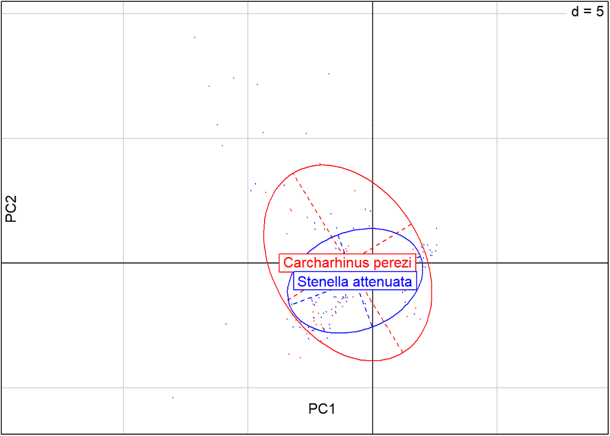

```r
## Generate plots
# PCA Scatter Plot
if ("occsBg" == "occs") {
  x <- espace_pca_Cp_Sa$scores[espace_pca_Cp_Sa$scores$bg == 'sp', ]
  x.f <- factor(x$sp)
} else if ("occsBg" == "occsBg") {
  x <- espace_pca_Cp_Sa$scores[espace_pca_Cp_Sa$scores$sp == 'bg', ]
  x.f <- factor(x$bg)
}
ade4::s.class(x, x.f, xax = 1, yax = 2,
              col = c("red", "blue"), cstar = 0, cpoint = 0.1)
title(xlab = paste0("PC", 1), ylab = paste0("PC", 2))
```

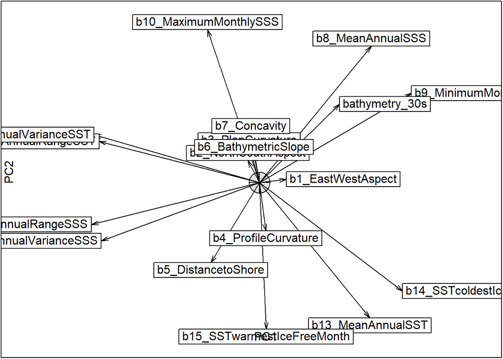

```r
# PCA Correlation circle
ade4::s.corcircle(espace_pca_Cp_Sa$co, xax = 1, yax = 2,
                  lab = pcaSel_Cp_Sa, full = FALSE, box = TRUE)
      title(xlab = paste0("PC", 1),
            ylab = paste0("PC", 2))
```

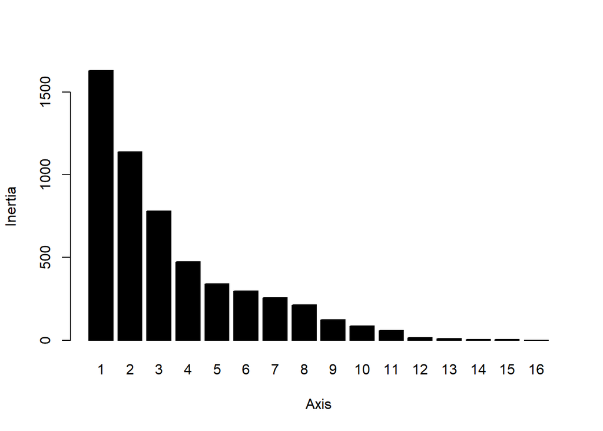

```r
# PCA screeplot
screeplot(espace_pca_Cp_Sa, main = NULL)
```

```r
# Print PCA summary of results
summary(espace_pca_Cp_Sa)
```

```
## Class: pca dudi
## Call: ade4::dudi.pca(df = data, row.w = bg > 0, center = TRUE, scale = TRUE,
##     scannf = FALSE, nf = ncol(data))
##
## Total inertia: 5436
##
## Eigenvalues:
##     Ax1     Ax2     Ax3     Ax4     Ax5
##  1630.9  1139.9   779.9   474.7   341.0
##
## Projected inertia (%):
##     Ax1     Ax2     Ax3     Ax4     Ax5
##  30.001  20.969  14.347   8.732   6.273
##
## Cumulative projected inertia (%):
##     Ax1   Ax1:2   Ax1:3   Ax1:4   Ax1:5
##   30.00   50.97   65.32   74.05   80.32
##
## (Only 5 dimensions (out of 16) are shown)
```